# New York City Job Openings!

Nicholas Stover

October 25, 2018

# Background

New York City is my wife’s dream life location! I support this location. I found some data on kaggle.com that has job openings! This will be an exciting project. I want to analyze this data and see what I can find. We are both interested in these results, even if they don’t provide much use.

First, I downloaded the data off the website. I am reading it in with the “readr” package.

# Clean

The data is very messy. It includes huge texts of job description and other not useful columns. I just want to visualize this data quickly and easily. I will remove some of these columns that don’t provide useful information for this project. These texts could definitely be useful later if we find some job openings that might be a fit for us!

Tidyverse is very useful for this.

```r
nyc_jobs$avgsalary <- (nyc_jobs$`Salary Range From` + nyc_jobs$`Salary Range To`)/2

nic_nyc_jobs <- nyc_jobs %>%
  ungroup() %>%
  select(-`Salary Range From`, -`Salary Range To`) %>%
  filter(avgsalary > 10000, nyc_jobs$`# Of Positions` < 100, str_detect(nyc_jobs$`Business Title` , '\\b(Analyst|Scientist|Data|Market|Research|Machine|Learning|Processing|Mining|Statistician|Statistics|Analytics)\\b'))


sadie_nyc_jobs <- nyc_jobs %>%
  ungroup() %>%
  select(-`Salary Range From`, -`Salary Range To`) %>%
  filter(avgsalary > 10000, nyc_jobs$`# Of Positions` < 100, str_detect(nyc_jobs$`Business Title` , '\\b(Design|Stylist|Designer|Textile|Textiles|Fashion|Creative|Buyer)\\b'))
```

# Visualize

The data is a little cleaner to visualize. It only includes the useful columns that might give use some info.

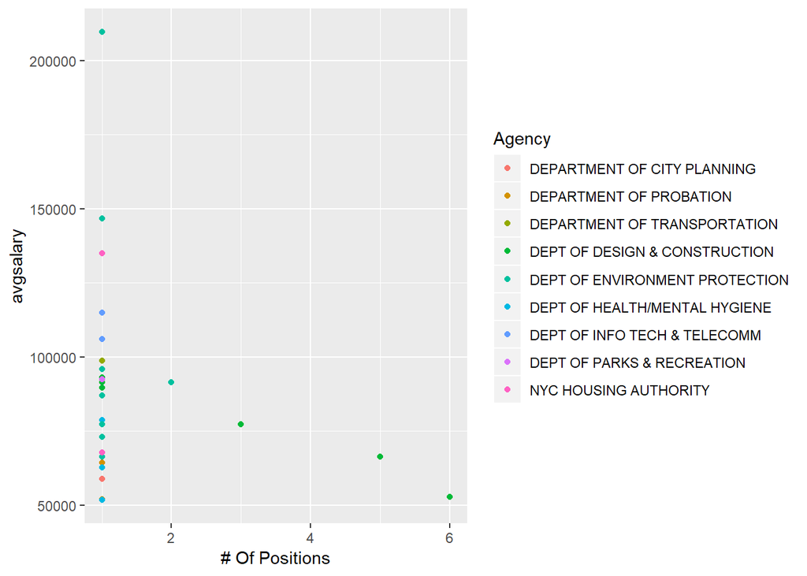

```r
nyc_jobs$Agency <- as.factor(nyc_jobs$Agency)
ggplot(sadie_nyc_jobs, aes(x=`# Of Positions`, y=avgsalary, color = Agency)) + geom_point()
```

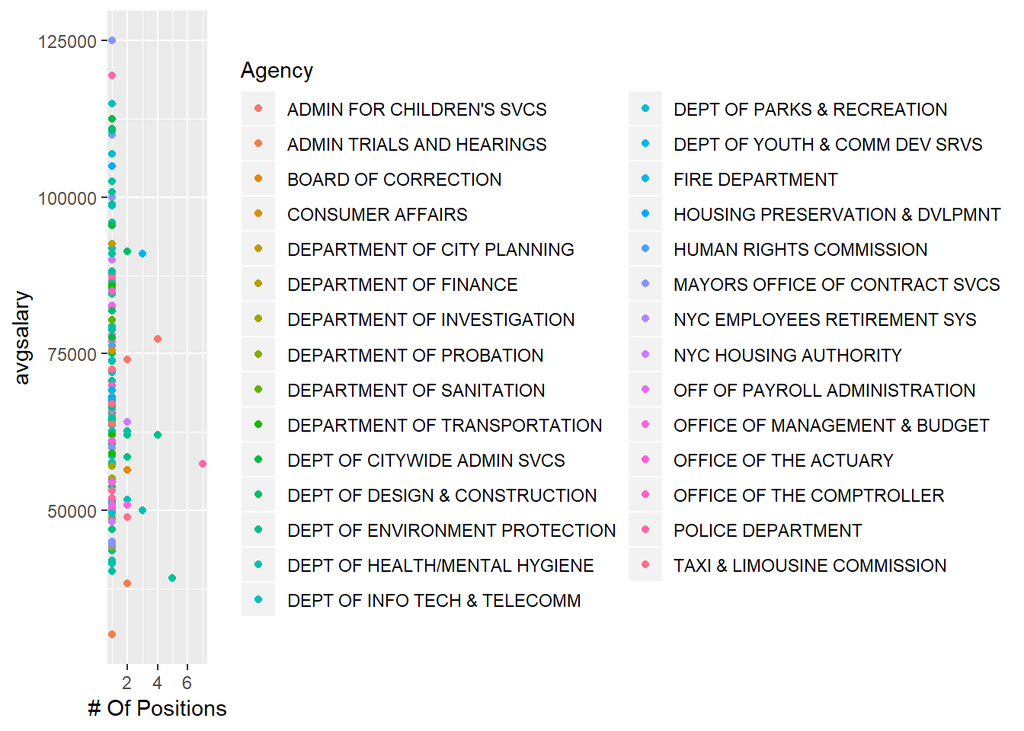

```r
ggplot(nic_nyc_jobs, aes(x=`# Of Positions`, y=avgsalary, color = Agency)) + geom_point()
```